# Week 4 Data Exploration

An exploration of centrality and centralization in the Florentine Families dataset

Lissie Bates-Haus https://github.com/lbateshaus (U Mass Amherst DACSS MS Student)https://www.umass.edu/sbs/data-analytics-and-computational-social-science-program/ms  
2022-02-16

First: copy over the import script provided:

```
#################################################################################################
"Florentine Families.R" has imported a network of weddings among powerful Florentine families.

This is a small, unweighted, undirected network stored as an adjacency matrix with no additional node or edge attributes. For more information use "?flo".

The import script has created three objects that represent the network:
     -network_adjacency     (an adjacency matrix containing edges and node names)
     -network_igraph        (an igraph object)
     -network_statnet       (a network object compatable with statnet packages like sna & ergm)

Each object name starts, quite generically, with "network_" and ends with the type of object it is. Note that the names are generic so that they are  compatable with other scripts you will use in this course. Feel free to rename the objects for your purposes.
################################################################################################
```

A brief description of the network:

```
 Network attributes:
  vertices = 16
  directed = FALSE
  hyper = FALSE
  loops = FALSE
  multiple = FALSE
  bipartite = FALSE
  total edges= 20
    missing edges= 0
    non-missing edges= 20

 Vertex attribute names:
    vertex.names

No edge attributes
```

```
[1] FALSE
```

```
[1] "name"
```

```
character(0)
```

Nodes are the names of 16 prominent families in Florentine during the earily 1400s. Ties are marriage connections between two families. This is an unweighted (binary), undirected graph.

First, we’ll take a brief look at the structure of this network.

```
[1] "membership" "csize"      "no"
```

```
[1] 2
```

```
[1] 15  1
```

```
     Mut Asym Null
[1,]  20    0  100
```

```
     003 012 102 021D 021U 021C 111D 111U 030T 030C 201 120D 120U
[1,] 324   0 195    0    0    0    0    0    0    0  38    0    0
     120C 210 300
[1,]    0   0   3
```

```
[1] 0.1914894
```

From here, we see there are two components in this graph: one consisting of fifteen of the elements, and one consisting of one (one isolate). This is an undirected graph so there are no asymmetrical dyads. Our global transitivity statistic is approximately 0.191.

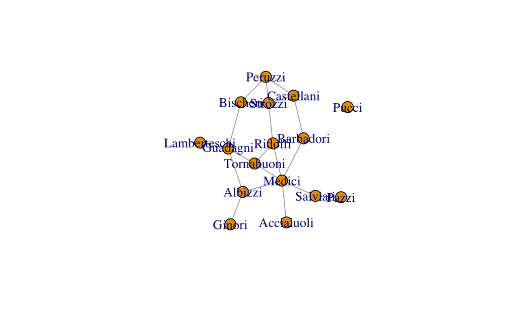

This plot is a visual representation of our two-component network, with 15 nodes conneted and 1 isolate (the Pucci family).

Now we’ll run some measures of centrality.

```
           name degree indegree outdegree      eigen   Bonacich
1    Acciaiuoli      2        1         1 0.13215429 -0.3796632
2       Albizzi      6        3         3 0.24395611 -2.0881476
3     Barbadori      4        2         2 0.21170525 -1.5186528
4      Bischeri      6        3         3 0.28280009  0.0000000
5    Castellani      6        3         3 0.25902617 -1.3288212
6        Ginori      2        1         1 0.07492271 -1.8983160
7      Guadagni      8        4         4 0.28911560 -0.1898316
8  Lamberteschi      2        1         1 0.08879189  0.0000000
9        Medici     12        6         6 0.43030809 -0.5694948
10        Pazzi      2        1         1 0.04481344  0.0000000
11      Peruzzi      6        3         3 0.27573037 -0.5694948
12        Pucci      0        0         0 0.00000000  0.0000000
13      Ridolfi      6        3         3 0.34155264  1.3288212
14     Salviati      4        2         2 0.14591720 -0.1898316
```

[output cut: 19 more lines]

The question is, now that we’ve calculated all of these scores, what do we do with them?

If we simply sort by degree:

```
           name degree indegree outdegree      eigen   Bonacich
1        Medici     12        6         6 0.43030809 -0.5694948
2      Guadagni      8        4         4 0.28911560 -0.1898316
3       Strozzi      8        4         4 0.35598045  0.1898316
4       Albizzi      6        3         3 0.24395611 -2.0881476
5      Bischeri      6        3         3 0.28280009  0.0000000
6    Castellani      6        3         3 0.25902617 -1.3288212
7       Peruzzi      6        3         3 0.27573037 -0.5694948
8       Ridolfi      6        3         3 0.34155264  1.3288212
9    Tornabuoni      6        3         3 0.32584230  1.1389896
10    Barbadori      4        2         2 0.21170525 -1.5186528
11     Salviati      4        2         2 0.14591720 -0.1898316
12   Acciaiuoli      2        1         1 0.13215429 -0.3796632
13       Ginori      2        1         1 0.07492271 -1.8983160
14 Lamberteschi      2        1         1 0.08879189  0.0000000
```

[output cut: 19 more lines]

We find, unsurprisingly, that the Medici family has the highest overall degree measure (12) as well as both the highest in- and out-degree measures, which suggest to me that the Medici family is the most highly connected of the Florentine Families. They also have the highest eigenvalue measure, which suggests again that they are most centrally connected and that they are connected to the most centrally connected other families.

Of note is the Bonacich measure:

```
           name degree indegree outdegree      eigen   Bonacich
1       Ridolfi      6        3         3 0.34155264  1.3288212
2    Tornabuoni      6        3         3 0.32584230  1.1389896
3       Strozzi      8        4         4 0.35598045  0.1898316
4      Bischeri      6        3         3 0.28280009  0.0000000
5  Lamberteschi      2        1         1 0.08879189  0.0000000
6         Pazzi      2        1         1 0.04481344  0.0000000
7         Pucci      0        0         0 0.00000000  0.0000000
8      Guadagni      8        4         4 0.28911560 -0.1898316
9      Salviati      4        2         2 0.14591720 -0.1898316
10   Acciaiuoli      2        1         1 0.13215429 -0.3796632
11       Medici     12        6         6 0.43030809 -0.5694948
12      Peruzzi      6        3         3 0.27573037 -0.5694948
13   Castellani      6        3         3 0.25902617 -1.3288212
14    Barbadori      4        2         2 0.21170525 -1.5186528
```

[output cut: 19 more lines]

This seems to be capturing something different about network position than the eigen score, and on this measure, the Medici family is at number 11. Per the [igraph documentation](https://igraph.org/r/doc/power_centrality.html):

“…positive values imply that vertices become more powerful as their alters become more powerful (as occurs in cooperative relations), while negative values imply that vertices become more powerful only as their alters become weaker (as occurs in competitive or antagonistic relations).”

Only three families have positive Bonacich scores (I am not sure how to interpret a Bonacich score of 0?).

The last measure I’ll look at is the reflected and derived centrality scores. Note: a higher score of eigen reflected centrality indicates the node may occupy a *hub* position.

```
           name degree indegree outdegree      eigen   Bonacich
1        Medici     12        6         6 0.43030809 -0.5694948
2       Strozzi      8        4         4 0.35598045  0.1898316
3      Guadagni      8        4         4 0.28911560 -0.1898316
4    Castellani      6        3         3 0.25902617 -1.3288212
5       Peruzzi      6        3         3 0.27573037 -0.5694948
6       Ridolfi      6        3         3 0.34155264  1.3288212
7      Bischeri      6        3         3 0.28280009  0.0000000
8    Tornabuoni      6        3         3 0.32584230  1.1389896
9       Albizzi      6        3         3 0.24395611 -2.0881476
10    Barbadori      4        2         2 0.21170525 -1.5186528
11     Salviati      4        2         2 0.14591720 -0.1898316
12       Ginori      2        1         1 0.07492271 -1.8983160
13        Pazzi      2        1         1 0.04481344  0.0000000
14 Lamberteschi      2        1         1 0.08879189  0.0000000
```

[output cut: 19 more lines]

By this metric, the Medici family is a hub, as well as the Strozzi and Guadagni families. If we look at our plot again, this makes sense.

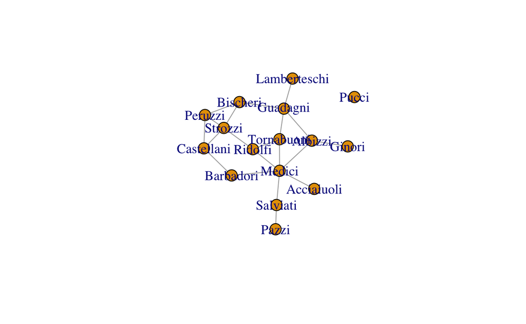

Recall that nodes with higher eigen derived centrality scores may occupy a *bridge* position.

```
           name degree indegree outdegree      eigen   Bonacich
1       Ridolfi      6        3         3 0.34155264  1.3288212
2    Tornabuoni      6        3         3 0.32584230  1.1389896
3        Medici     12        6         6 0.43030809 -0.5694948
4       Strozzi      8        4         4 0.35598045  0.1898316
5      Bischeri      6        3         3 0.28280009  0.0000000
6       Peruzzi      6        3         3 0.27573037 -0.5694948
7       Albizzi      6        3         3 0.24395611 -2.0881476
8      Guadagni      8        4         4 0.28911560 -0.1898316
9    Castellani      6        3         3 0.25902617 -1.3288212
10    Barbadori      4        2         2 0.21170525 -1.5186528
11   Acciaiuoli      2        1         1 0.13215429 -0.3796632
12     Salviati      4        2         2 0.14591720 -0.1898316
13 Lamberteschi      2        1         1 0.08879189  0.0000000
14       Ginori      2        1         1 0.07492271 -1.8983160
```

[output cut: 19 more lines]

By this measure, the Ridolfi and Tornabuoni occupy bridge positions. Of note is that the Medici family is also high on this list, which perhaps speaks to the centrality of that family, regardless of measure.